# Expansión de la CASEN sobre el CENSO (Región 02)

De ingresos sobre una categoría de respuesta **RURAL

VE-CC-AJ

DataIntelligence

Martes 06-07-2021

Abstract

Expandiremos los ingresos promedios comunales obtenidos de la CASEN sobre la pregunta (P15): “Nivel del curso más alto aprobado” en la categoría de respuesta “Profesional” (12), que más alto correlaciona con los ingresos expandidos (obtenidos de la multiplicación del ingreso promedio y los habitantes), ambos a nivel comunal.

Haremos el análisis sobre la región 02.

Ensayaremos diferentes modelos dentro del análisis de regresión cuya variable independiente será: “frecuencia de población que posee la variable Censal respecto a la zona” y la dependiente: “ingreso expandido de la Casen por zona”

Lo anterior para ir combinando a nivel nacional los mejores modelos para construir una tabla de valores predichos.

## 1 Variable CENSO

Necesitamos calcular las frecuencias a nivel censal de las respuestas correspondientes a la categoría: “Profesional (4 o más años)” del campo **P15** a nivel **rural** del Censo de personas. Recordemos que ésta fué la más alta correlación en relación a los ingresos expandidos [(ver punto 3.4 aquí)](https://rpubs.com/dataintelligence/corr_censo_casen_2017).

### 1.1 Lectura y filtrado de la tabla censal de personas

Leemos la tabla Censo 2017 de personas que ya tiene integrada la clave zonal:

```r
tabla_con_clave <- readRDS("../censo_personas_con_clave_17")
r3_100 <- tabla_con_clave[c(1:100),]
kbl(r3_100) %>%
  kable_styling(bootstrap_options = c("striped", "hover")) %>%
  kable_paper() %>%
  scroll_box(width = "100%", height = "300px")
```

| REGION | PROVINCIA | COMUNA | DC | AREA | ZC_LOC | ID_ZONA_LOC | NVIV | NHOGAR | PERSONAN | P07 | P08 | P09 | P10 | P10COMUNA | P10PAIS | P11 | P11COMUNA | P11PAIS | P12 | P12COMUNA | P12PAIS | P12A_LLEGADA | P12A_TRAMO | P13 | P14 | P15 | P15A | P16 | P16A | … |
| --- | --- | --- | --- | --- | --- | --- | --- | --- | --- | --- | --- | --- | --- | --- | --- | --- | --- | --- | --- | --- | --- | --- | --- | --- | --- | --- | --- | --- | --- | --- |
| 15 | 152 | 15202 | 1 | 2 | 6 | 13225 | 1 | 1 | 1 | 1 | 1 | 73 | 1 | 98 | 998 | 3 | 15101 | 998 | 1 | 98 | 998 | 9998 | 98 | 2 | 4 | 6 | 2 | 1 | 2 | … |
| 15 | 152 | 15202 | 1 | 2 | 6 | 13225 | 3 | 1 | 1 | 1 | 1 | 78 | 1 | 98 | 998 | 2 | 98 | 998 | 1 | 98 | 998 | 9998 | 98 | 3 | 98 | 98 | 98 | 1 | 2 | … |
| 15 | 152 | 15202 | 1 | 2 | 6 | 13225 | 3 | 1 | 2 | 2 | 2 | 78 | 1 | 98 | 998 | 2 | 98 | 998 | 1 | 98 | 998 | 9998 | 98 | 3 | 98 | 98 | 98 | 1 | 2 | … |
| 15 | 152 | 15202 | 1 | 2 | 6 | 13225 | 3 | 1 | 3 | 5 | 2 | 52 | 1 | 98 | 998 | 2 | 98 | 998 | 1 | 98 | 998 | 9998 | 98 | 1 | 2 | 5 | 2 | 1 | 2 | … |
| 15 | 152 | 15202 | 1 | 2 | 6 | 13225 | 3 | 1 | 4 | 11 | 1 | 44 | 1 | 98 | 998 | 2 | 98 | 998 | 1 | 98 | 998 | 9998 | 98 | 1 | 3 | 5 | 2 | 1 | 2 | … |
| 15 | 152 | 15202 | 1 | 2 | 6 | 13225 | 9 | 1 | 1 | 1 | 1 | 39 | 1 | 98 | 998 | 2 | 98 | 998 | 1 | 98 | 998 | 9998 | 98 | 2 | 8 | 5 | 1 | 1 | 2 | … |
| 15 | 152 | 15202 | 1 | 2 | 6 | 13225 | 9 | 1 | 2 | 2 | 2 | 35 | 1 | 98 | 998 | 2 | 98 | 998 | 1 | 98 | 998 | 9998 | 98 | 2 | 6 | 5 | 2 | 1 | 2 | … |
| 15 | 152 | 15202 | 1 | 2 | 6 | 13225 | 9 | 1 | 3 | 5 | 1 | 13 | 1 | 98 | 998 | 2 | 98 | 998 | 1 | 98 | 998 | 9998 | 98 | 1 | 7 | 5 | 2 | 1 | 2 | … |
| 15 | 152 | 15202 | 1 | 2 | 6 | 13225 | 9 | 1 | 4 | 5 | 1 | 12 | 1 | 98 | 998 | 2 | 98 | 998 | 1 | 98 | 998 | 9998 | 98 | 1 | 6 | 5 | 2 | 1 | 2 | … |
| 15 | 152 | 15202 | 1 | 2 | 6 | 13225 | 10 | 1 | 1 | 1 | 2 | 65 | 1 | 98 | 998 | 2 | 98 | 998 | 1 | 98 | 998 | 9998 | 98 | 2 | 4 | 5 | 2 | 1 | 2 | … |
| 15 | 152 | 15202 | 1 | 2 | 6 | 13225 | 13 | 1 | 1 | 1 | 1 | 50 | 1 | 98 | 998 | 2 | 98 | 998 | 1 | 98 | 998 | 9998 | 98 | 2 | 5 | 5 | 2 | 1 | 2 | … |
| 15 | 152 | 15202 | 1 | 2 | 6 | 13225 | 13 | 1 | 2 | 4 | 2 | 43 | 1 | 98 | 998 | 2 | 98 | 998 | 1 | 98 | 998 | 9998 | 98 | 2 | 6 | 5 | 2 | 1 | 2 | … |
| 15 | 152 | 15202 | 1 | 2 | 6 | 13225 | 13 | 1 | 3 | 5 | 1 | 15 | 3 | 15201 | 998 | 2 | 98 | 998 | 1 | 98 | 998 | 9998 | 98 | 1 | 1 | 7 | 2 | 1 | 2 | … |
| 15 | 152 | 15202 | 1 | 2 | 6 | 13225 | 16 | 1 | 1 | 1 | 1 | 75 | 1 | 98 | 998 | 2 | 98 | 998 | 1 | 98 | 998 | 9998 | 98 | 3 | 98 | 98 | 98 | 1 | 2 | … |
| 15 | 152 | 15202 | 1 | 2 | 6 | 13225 | 16 | 1 | 2 | 16 | 2 | 58 | 4 | 98 | 68 | 6 | 98 | 998 | 5 | 98 | 998 | 9999 | 1 | 3 | 98 | 98 | 98 | 1 | 2 | … |
| 15 | 152 | 15202 | 1 | 2 | 6 | 13225 | 16 | 1 | 3 | 2 | 2 | 70 | 1 | 98 | 998 | 2 | 98 | 998 | 1 | 98 | 998 | 9998 | 98 | 3 | 98 | 98 | 98 | 1 | 2 | … |
| 15 | 152 | 15202 | 1 | 2 | 6 | 13225 | 17 | 1 | 1 | 1 | 2 | 43 | 2 | 98 | 998 | 2 | 98 | 998 | 1 | 98 | 998 | 9998 | 98 | 2 | 8 | 5 | 1 | 1 | 2 | … |
| 15 | 152 | 15202 | 1 | 2 | 6 | 13225 | 17 | 1 | 2 | 4 | 1 | 55 | 2 | 98 | 998 | 2 | 98 | 998 | 1 | 98 | 998 | 9998 | 98 | 2 | 6 | 5 | 2 | 1 | 2 | … |
| 15 | 152 | 15202 | 1 | 2 | 6 | 13225 | 17 | 1 | 3 | 5 | 2 | 13 | 2 | 98 | 998 | 2 | 98 | 998 | 2 | 15101 | 998 | 9998 | 98 | 1 | 7 | 5 | 2 | 1 | 2 | … |
| 15 | 152 | 15202 | 1 | 2 | 6 | 13225 | 17 | 1 | 4 | 5 | 1 | 8 | 2 | 98 | 998 | 2 | 98 | 998 | 2 | 15101 | 998 | 9998 | 98 | 1 | 2 | 5 | 2 | 1 | 2 | … |
| 15 | 152 | 15202 | 1 | 2 | 6 | 13225 | 17 | 1 | 5 | 15 | 2 | 29 | 2 | 98 | 998 | 4 | 98 | 998 | 3 | 98 | 998 | 2015 | 1 | 2 | 6 | 5 | 2 | 1 | 2 | … |
| 15 | 152 | 15202 | 1 | 2 | 6 | 13225 | 17 | 1 | 6 | 15 | 1 | 4 | 2 | 98 | 998 | 1 | 98 | 998 | 5 | 98 | 998 | 2015 | 1 | 1 | 0 | 1 | 2 | 1 | 2 | … |
| 15 | 152 | 15202 | 1 | 2 | 6 | 13225 | 17 | 1 | 7 | 15 | 2 | 2 | 2 | 98 | 998 | 1 | 98 | 998 | 3 | 98 | 998 | 2015 | 1 | 1 | 0 | 1 | 2 | 1 | 2 | … |
| 15 | 152 | 15202 | 1 | 2 | 6 | 13225 | 17 | 1 | 8 | 15 | 1 | 16 | 2 | 98 | 998 | 6 | 98 | 998 | 1 | 98 | 998 | 9998 | 98 | 2 | 4 | 5 | 2 | 1 | 2 | … |
| 15 | 152 | 15202 | 1 | 2 | 6 | 13225 | 18 | 1 | 1 | 1 | 2 | 74 | 1 | 98 | 998 | 2 | 98 | 998 | 1 | 98 | 998 | 9998 | 98 | 2 | 2 | 5 | 2 | 1 | 2 | … |
| 15 | 152 | 15202 | 1 | 2 | 6 | 13225 | 19 | 1 | 1 | 1 | 1 | 68 | 1 | 98 | 998 | 2 | 98 | 998 | 1 | 98 | 998 | 9998 | 98 | 3 | 98 | 98 | 98 | 1 | 2 | … |
| 15 | 152 | 15202 | 1 | 2 | 6 | 13225 | 20 | 1 | 1 | 1 | 1 | 74 | 1 | 98 | 998 | 3 | 15101 | 998 | 1 | 98 | 998 | 9998 | 98 | 2 | 2 | 5 | 2 | 1 | 2 | … |
| 15 | 152 | 15202 | 1 | 2 | 6 | 13225 | 20 | 1 | 2 | 2 | 2 | 65 | 1 | 98 | 998 | 3 | 997 | 998 | 3 | 98 | 998 | 9999 | 2 | 2 | 2 | 5 | 2 | 1 | 2 | … |
| 15 | 152 | 15202 | 1 | 2 | 6 | 13225 | 25 | 1 | 1 | 1 | 2 | 76 | 1 | 98 | 998 | 2 | 98 | 998 | 1 | 98 | 998 | 9998 | 98 | 3 | 98 | 98 | 98 | 1 | 2 | … |
| 15 | 152 | 15202 | 1 | 2 | 6 | 13225 | 25 | 1 | 2 | 5 | 2 | 36 | 1 | 98 | 998 | 2 | 98 | 998 | 1 | 98 | 998 | 9998 | 98 | 2 | 4 | 8 | 1 | 1 | 2 | … |

[output cut: 70 more lines]

Despleguemos los códigos de regiones de nuestra tabla:

```r
regiones <- unique(tabla_con_clave$REGION)
regiones
```

```
##  [1] 15 14 13 12 11 10  9 16  8  7  6  5  4  3  2  1
```

Hagamos un subset con la region 02 y con la zona = 2:

```r
tabla_con_clave <- filter(tabla_con_clave, tabla_con_clave$REGION == 2)
tabla_con_clave <- filter(tabla_con_clave, tabla_con_clave$AREA== 2)
```

### 1.2 Cálculo de frecuencias

```r
tabla_con_clave_f <- tabla_con_clave[,-c(1,2,4,5,6,7,8,9,10,11,13,14,15,16,17,18,19,20),drop=FALSE]
```

```r
names(tabla_con_clave_f)[9] <- "Nivel del curso más alto aprobado"
```

```r
# Ahora filtramos por Nivel del curso más alto aprobado = 11.
tabla_con_clave_ff <- filter(tabla_con_clave_f, tabla_con_clave_f$`Nivel del curso más alto aprobado` == 12)
```

```r
# Determinamos las frecuencias por zona:
b <- tabla_con_clave_ff$clave
c <- tabla_con_clave_ff$`Nivel del curso más alto aprobado`
d <- tabla_con_clave_ff$COMUNA
cross_tab =  xtabs( ~ unlist(b) + unlist(c)+ unlist(d))
tabla <- as.data.frame(cross_tab)
d <-tabla[!(tabla$Freq == 0),]
names(d)[1] <- "zona"
d$anio <- "2017"
```

Veamos los primeros 100 registros:

```r
r3_100 <- d[c(1:100),]
kbl(r3_100) %>%
  kable_styling(bootstrap_options = c("striped", "hover")) %>%
  kable_paper() %>%
  scroll_box(width = "100%", height = "300px")
```

|  | zona | unlist.c. | unlist.d. | Freq | anio |
| --- | --- | --- | --- | --- | --- |
| 1 | 2101012012 | 12 | 2101 | 3 | 2017 |
| 2 | 2101012013 | 12 | 2101 | 12 | 2017 |
| 3 | 2101102007 | 12 | 2101 | 24 | 2017 |
| 4 | 2101102016 | 12 | 2101 | 1 | 2017 |
| 5 | 2101112011 | 12 | 2101 | 288 | 2017 |
| 6 | 2101122008 | 12 | 2101 | 804 | 2017 |
| 7 | 2101122014 | 12 | 2101 | 14 | 2017 |
| 8 | 2101122019 | 12 | 2101 | 25 | 2017 |
| 9 | 2101132020 | 12 | 2101 | 1 | 2017 |
| 79 | 2102022003 | 12 | 2102 | 31 | 2017 |
| 80 | 2102022006 | 12 | 2102 | 14 | 2017 |
| 81 | 2102022008 | 12 | 2102 | 2 | 2017 |
| 82 | 2102022901 | 12 | 2102 | 1 | 2017 |
| 152 | 2103012003 | 12 | 2103 | 900 | 2017 |
| 153 | 2103012008 | 12 | 2103 | 645 | 2017 |
| 154 | 2103012901 | 12 | 2103 | 1 | 2017 |
| 155 | 2103022006 | 12 | 2103 | 118 | 2017 |
| 156 | 2103022007 | 12 | 2103 | 299 | 2017 |
| 157 | 2103022008 | 12 | 2103 | 273 | 2017 |
| 158 | 2103032002 | 12 | 2103 | 38 | 2017 |
| 159 | 2103042001 | 12 | 2103 | 22 | 2017 |
| 160 | 2103042005 | 12 | 2103 | 1 | 2017 |
| 161 | 2103992999 | 12 | 2103 | 9 | 2017 |
| 231 | 2104012008 | 12 | 2104 | 1 | 2017 |
| 232 | 2104022015 | 12 | 2104 | 7 | 2017 |
| 233 | 2104022022 | 12 | 2104 | 2 | 2017 |
| 234 | 2104022901 | 12 | 2104 | 1 | 2017 |
| 235 | 2104032025 | 12 | 2104 | 1 | 2017 |
| 236 | 2104042020 | 12 | 2104 | 60 | 2017 |
| 237 | 2104052026 | 12 | 2104 | 2 | 2017 |

[output cut: 70 more lines]

Agregamos un cero a los códigos comunales de cuatro dígitos:

```r
codigos <- d$unlist.d.
rango <- seq(1:nrow(d))
cadena <- paste("0",codigos[rango], sep = "")
cadena <- substr(cadena,(nchar(cadena)[rango])-(4),6)
codigos <- as.data.frame(codigos)
cadena <- as.data.frame(cadena)
comuna_corr <- cbind(d,cadena)
comuna_corr <- comuna_corr[,-c(2,3),drop=FALSE]
names(comuna_corr)[4] <- "código"
r3_100 <- comuna_corr[c(1:100),]
kbl(r3_100) %>%
  kable_styling(bootstrap_options = c("striped", "hover")) %>%
  kable_paper() %>%
  scroll_box(width = "100%", height = "300px")
```

|  | zona | Freq | anio | código |
| --- | --- | --- | --- | --- |
| 1 | 2101012012 | 3 | 2017 | 02101 |
| 2 | 2101012013 | 12 | 2017 | 02101 |
| 3 | 2101102007 | 24 | 2017 | 02101 |
| 4 | 2101102016 | 1 | 2017 | 02101 |
| 5 | 2101112011 | 288 | 2017 | 02101 |
| 6 | 2101122008 | 804 | 2017 | 02101 |
| 7 | 2101122014 | 14 | 2017 | 02101 |
| 8 | 2101122019 | 25 | 2017 | 02101 |
| 9 | 2101132020 | 1 | 2017 | 02101 |
| 79 | 2102022003 | 31 | 2017 | 02102 |
| 80 | 2102022006 | 14 | 2017 | 02102 |
| 81 | 2102022008 | 2 | 2017 | 02102 |
| 82 | 2102022901 | 1 | 2017 | 02102 |
| 152 | 2103012003 | 900 | 2017 | 02103 |
| 153 | 2103012008 | 645 | 2017 | 02103 |
| 154 | 2103012901 | 1 | 2017 | 02103 |
| 155 | 2103022006 | 118 | 2017 | 02103 |
| 156 | 2103022007 | 299 | 2017 | 02103 |
| 157 | 2103022008 | 273 | 2017 | 02103 |
| 158 | 2103032002 | 38 | 2017 | 02103 |
| 159 | 2103042001 | 22 | 2017 | 02103 |
| 160 | 2103042005 | 1 | 2017 | 02103 |
| 161 | 2103992999 | 9 | 2017 | 02103 |
| 231 | 2104012008 | 1 | 2017 | 02104 |
| 232 | 2104022015 | 7 | 2017 | 02104 |
| 233 | 2104022022 | 2 | 2017 | 02104 |
| 234 | 2104022901 | 1 | 2017 | 02104 |
| 235 | 2104032025 | 1 | 2017 | 02104 |
| 236 | 2104042020 | 60 | 2017 | 02104 |
| 237 | 2104052026 | 2 | 2017 | 02104 |

[output cut: 70 more lines]

## 2 Variable CASEN

### 2.1 Tabla de ingresos expandidos

Hemos calculado ya éste valor como conclusión del punto 1.1 de [aquí](https://rpubs.com/dataintelligence/corr_casen_censo_002)

```r
h_y_m_2017_censo <- readRDS("../corre_ing_exp-censo_casen/Ingresos_expandidos_rural_17.rds")
tablamadre <- head(h_y_m_2017_censo,50)
kbl(tablamadre) %>%
  kable_styling(bootstrap_options = c("striped", "hover")) %>%
  kable_paper() %>%
  scroll_box(width = "100%", height = "300px")
```

| código | comuna.x | promedio_i | año | personas | Ingresos_expandidos |
| --- | --- | --- | --- | --- | --- |
| 01101 | Iquique | 272529.7 | 2017 | 191468 | 52180713221 |
| 01401 | Pozo Almonte | 243272.4 | 2017 | 15711 | 3822052676 |
| 01402 | Camiña | 226831.0 | 2017 | 1250 | 283538750 |
| 01404 | Huara | 236599.7 | 2017 | 2730 | 645917134 |
| 01405 | Pica | 269198.0 | 2017 | 9296 | 2502464414 |
| 02103 | Sierra Gorda | 322997.9 | 2017 | 10186 | 3290056742 |
| 02104 | Taltal | 288653.8 | 2017 | 13317 | 3844002134 |
| 02201 | Calama | 238080.9 | 2017 | 165731 | 39457387800 |
| 02203 | San Pedro de Atacama | 271472.6 | 2017 | 10996 | 2985112297 |
| 02301 | Tocopilla | 166115.9 | 2017 | 25186 | 4183793832 |
| 03101 | Copiapó | 251396.0 | 2017 | 153937 | 38699138722 |
| 03103 | Tierra Amarilla | 287819.4 | 2017 | 14019 | 4034940816 |
| 03202 | Diego de Almagro | 326439.0 | 2017 | 13925 | 4545663075 |
| 03301 | Vallenar | 217644.6 | 2017 | 51917 | 11299454698 |
| 03302 | Alto del Carmen | 196109.9 | 2017 | 5299 | 1039186477 |
| 03303 | Freirina | 202463.8 | 2017 | 7041 | 1425547554 |
| 03304 | Huasco | 205839.6 | 2017 | 10149 | 2089066548 |
| 04101 | La Serena | 200287.4 | 2017 | 221054 | 44274327972 |
| 04102 | Coquimbo | 206027.8 | 2017 | 227730 | 46918711304 |
| 04103 | Andacollo | 217096.4 | 2017 | 11044 | 2397612293 |
| 04104 | La Higuera | 231674.2 | 2017 | 4241 | 982530309 |
| 04105 | Paiguano | 174868.5 | 2017 | 4497 | 786383423 |
| 04106 | Vicuña | 169077.1 | 2017 | 27771 | 4695441470 |
| 04201 | Illapel | 165639.6 | 2017 | 30848 | 5109649759 |
| 04202 | Canela | 171370.3 | 2017 | 9093 | 1558270441 |
| 04203 | Los Vilos | 173238.5 | 2017 | 21382 | 3704185607 |
| 04204 | Salamanca | 193602.0 | 2017 | 29347 | 5681637894 |
| 04301 | Ovalle | 230819.8 | 2017 | 111272 | 25683781418 |
| 04302 | Combarbalá | 172709.2 | 2017 | 13322 | 2300832587 |
| 04303 | Monte Patria | 189761.6 | 2017 | 30751 | 5835357638 |
| 04304 | Punitaqui | 165862.0 | 2017 | 10956 | 1817183694 |
| 04305 | Río Hurtado | 182027.2 | 2017 | 4278 | 778712384 |
| 05101 | Valparaíso | 251998.5 | 2017 | 296655 | 74756602991 |
| 05102 | Casablanca | 252317.7 | 2017 | 26867 | 6779018483 |
| 05105 | Puchuncaví | 231606.0 | 2017 | 18546 | 4295363979 |
| 05107 | Quintero | 285125.8 | 2017 | 31923 | 9102071069 |
| 05301 | Los Andes | 280548.0 | 2017 | 66708 | 18714795984 |
| 05302 | Calle Larga | 234044.6 | 2017 | 14832 | 3471349123 |
| 05303 | Rinconada | 246136.9 | 2017 | 10207 | 2512319225 |
| 05304 | San Esteban | 211907.3 | 2017 | 18855 | 3995512770 |
| 05401 | La Ligua | 172675.9 | 2017 | 35390 | 6111000517 |
| 05402 | Cabildo | 212985.0 | 2017 | 19388 | 4129354103 |
| 05404 | Petorca | 270139.8 | 2017 | 9826 | 2654393853 |
| 05405 | Zapallar | 235661.4 | 2017 | 7339 | 1729518700 |
| 05501 | Quillota | 212067.6 | 2017 | 90517 | 19195726144 |
| 05502 | Calera | 226906.2 | 2017 | 50554 | 11471016698 |
| 05503 | Hijuelas | 215402.0 | 2017 | 17988 | 3874650405 |
| 05504 | La Cruz | 243333.4 | 2017 | 22098 | 5377180726 |
| 05506 | Nogales | 219800.7 | 2017 | 22120 | 4861992055 |
| 05601 | San Antonio | 230261.5 | 2017 | 91350 | 21034388728 |

## 3 Unión Censo-Casen

Integramos a la tabla censal de frecuencias la tabla de ingresos expandidos de la Casen.

```r
comunas_con_ing_exp = merge( x = comuna_corr, y = h_y_m_2017_censo, by = "código", all.x = TRUE)

comunas_con_ing_exp <-comunas_con_ing_exp[!(is.na(comunas_con_ing_exp$Ingresos_expandidos)),]

r3_100 <- comunas_con_ing_exp
kbl(r3_100) %>%
  kable_styling(bootstrap_options = c("striped", "hover")) %>%
  kable_paper() %>%
  scroll_box(width = "100%", height = "300px")
```

|  | código | zona | Freq | anio | comuna.x | promedio_i | año | personas | Ingresos_expandidos |
| --- | --- | --- | --- | --- | --- | --- | --- | --- | --- |
| 14 | 02103 | 2103042001 | 22 | 2017 | Sierra Gorda | 322997.9 | 2017 | 10186 | 3290056742 |
| 15 | 02103 | 2103022008 | 273 | 2017 | Sierra Gorda | 322997.9 | 2017 | 10186 | 3290056742 |
| 16 | 02103 | 2103032002 | 38 | 2017 | Sierra Gorda | 322997.9 | 2017 | 10186 | 3290056742 |
| 17 | 02103 | 2103012901 | 1 | 2017 | Sierra Gorda | 322997.9 | 2017 | 10186 | 3290056742 |
| 18 | 02103 | 2103022007 | 299 | 2017 | Sierra Gorda | 322997.9 | 2017 | 10186 | 3290056742 |
| 19 | 02103 | 2103012003 | 900 | 2017 | Sierra Gorda | 322997.9 | 2017 | 10186 | 3290056742 |
| 20 | 02103 | 2103012008 | 645 | 2017 | Sierra Gorda | 322997.9 | 2017 | 10186 | 3290056742 |
| 21 | 02103 | 2103022006 | 118 | 2017 | Sierra Gorda | 322997.9 | 2017 | 10186 | 3290056742 |
| 22 | 02103 | 2103042005 | 1 | 2017 | Sierra Gorda | 322997.9 | 2017 | 10186 | 3290056742 |
| 23 | 02103 | 2103992999 | 9 | 2017 | Sierra Gorda | 322997.9 | 2017 | 10186 | 3290056742 |
| 24 | 02104 | 2104022015 | 7 | 2017 | Taltal | 288653.8 | 2017 | 13317 | 3844002134 |
| 25 | 02104 | 2104092002 | 19 | 2017 | Taltal | 288653.8 | 2017 | 13317 | 3844002134 |
| 26 | 02104 | 2104092012 | 79 | 2017 | Taltal | 288653.8 | 2017 | 13317 | 3844002134 |
| 27 | 02104 | 2104052027 | 1 | 2017 | Taltal | 288653.8 | 2017 | 13317 | 3844002134 |
| 28 | 02104 | 2104082013 | 74 | 2017 | Taltal | 288653.8 | 2017 | 13317 | 3844002134 |
| 29 | 02104 | 2104012008 | 1 | 2017 | Taltal | 288653.8 | 2017 | 13317 | 3844002134 |
| 30 | 02104 | 2104042020 | 60 | 2017 | Taltal | 288653.8 | 2017 | 13317 | 3844002134 |
| 31 | 02104 | 2104022022 | 2 | 2017 | Taltal | 288653.8 | 2017 | 13317 | 3844002134 |
| 32 | 02104 | 2104022901 | 1 | 2017 | Taltal | 288653.8 | 2017 | 13317 | 3844002134 |
| 33 | 02104 | 2104032025 | 1 | 2017 | Taltal | 288653.8 | 2017 | 13317 | 3844002134 |
| 34 | 02104 | 2104052026 | 2 | 2017 | Taltal | 288653.8 | 2017 | 13317 | 3844002134 |
| 35 | 02201 | 2201082002 | 32 | 2017 | Calama | 238080.9 | 2017 | 165731 | 39457387800 |
| 36 | 02201 | 2201132901 | 9 | 2017 | Calama | 238080.9 | 2017 | 165731 | 39457387800 |
| 37 | 02201 | 2201142002 | 17 | 2017 | Calama | 238080.9 | 2017 | 165731 | 39457387800 |
| 38 | 02201 | 2201152003 | 1 | 2017 | Calama | 238080.9 | 2017 | 165731 | 39457387800 |
| 39 | 02201 | 2201152009 | 1 | 2017 | Calama | 238080.9 | 2017 | 165731 | 39457387800 |
| 40 | 02201 | 2201022005 | 651 | 2017 | Calama | 238080.9 | 2017 | 165731 | 39457387800 |
| 41 | 02201 | 2201032006 | 5 | 2017 | Calama | 238080.9 | 2017 | 165731 | 39457387800 |
| 42 | 02201 | 2201052005 | 217 | 2017 | Calama | 238080.9 | 2017 | 165731 | 39457387800 |
| 43 | 02201 | 2201132004 | 48 | 2017 | Calama | 238080.9 | 2017 | 165731 | 39457387800 |
| 44 | 02201 | 2201082012 | 11 | 2017 | Calama | 238080.9 | 2017 | 165731 | 39457387800 |
| 45 | 02201 | 2201122002 | 2 | 2017 | Calama | 238080.9 | 2017 | 165731 | 39457387800 |
| 46 | 02201 | 2201122005 | 10 | 2017 | Calama | 238080.9 | 2017 | 165731 | 39457387800 |
| 47 | 02201 | 2201132010 | 6 | 2017 | Calama | 238080.9 | 2017 | 165731 | 39457387800 |
| 51 | 02203 | 2203012014 | 607 | 2017 | San Pedro de Atacama | 271472.6 | 2017 | 10996 | 2985112297 |
| 52 | 02203 | 2203022017 | 60 | 2017 | San Pedro de Atacama | 271472.6 | 2017 | 10996 | 2985112297 |
| 53 | 02203 | 2203032012 | 206 | 2017 | San Pedro de Atacama | 271472.6 | 2017 | 10996 | 2985112297 |
| 54 | 02203 | 2203032015 | 13 | 2017 | San Pedro de Atacama | 271472.6 | 2017 | 10996 | 2985112297 |
| 55 | 02203 | 2203022011 | 1 | 2017 | San Pedro de Atacama | 271472.6 | 2017 | 10996 | 2985112297 |
| 56 | 02203 | 2203012018 | 1 | 2017 | San Pedro de Atacama | 271472.6 | 2017 | 10996 | 2985112297 |
| 57 | 02203 | 2203012901 | 1 | 2017 | San Pedro de Atacama | 271472.6 | 2017 | 10996 | 2985112297 |
| 58 | 02203 | 2203022008 | 2 | 2017 | San Pedro de Atacama | 271472.6 | 2017 | 10996 | 2985112297 |
| 59 | 02203 | 2203022016 | 5 | 2017 | San Pedro de Atacama | 271472.6 | 2017 | 10996 | 2985112297 |
| 60 | 02301 | 2301032006 | 6 | 2017 | Tocopilla | 166115.9 | 2017 | 25186 | 4183793832 |
| 61 | 02301 | 2301052008 | 1 | 2017 | Tocopilla | 166115.9 | 2017 | 25186 | 4183793832 |
| 62 | 02301 | 2301052016 | 1 | 2017 | Tocopilla | 166115.9 | 2017 | 25186 | 4183793832 |
| 63 | 02301 | 2301052019 | 1 | 2017 | Tocopilla | 166115.9 | 2017 | 25186 | 4183793832 |
| 64 | 02301 | 2301052004 | 1 | 2017 | Tocopilla | 166115.9 | 2017 | 25186 | 4183793832 |

## 4 Proporción poblacional zonal respecto a la comunal

Del censo obtenemos la cantidad de población a nivel de zona y estimamos su proporción a nivel comunal. Ya hemos calculado ésta proporción [aquí](https://rpubs.com/dataintelligence/tabla_de_proporciones).

```r
prop_pob <- readRDS("../tabla_de_prop_pob.rds")
names(prop_pob)[1] <- "zona"
names(prop_pob)[3] <- "p_poblacional"
```

Veamos los 100 primeros registros:

```r
r3_100 <- prop_pob[c(1:100),]
kbl(r3_100) %>%
  kable_styling(bootstrap_options = c("striped", "hover")) %>%
  kable_paper() %>%
  scroll_box(width = "100%", height = "300px")
```

| zona | Freq | p_poblacional | código |
| --- | --- | --- | --- |
| 1101011001 | 2491 | 0.0130100 | 01101 |
| 1101011002 | 1475 | 0.0077036 | 01101 |
| 1101021001 | 1003 | 0.0052385 | 01101 |
| 1101021002 | 54 | 0.0002820 | 01101 |
| 1101021003 | 2895 | 0.0151200 | 01101 |
| 1101021004 | 2398 | 0.0125243 | 01101 |
| 1101021005 | 4525 | 0.0236332 | 01101 |
| 1101031001 | 2725 | 0.0142321 | 01101 |
| 1101031002 | 3554 | 0.0185618 | 01101 |
| 1101031003 | 5246 | 0.0273988 | 01101 |
| 1101031004 | 3389 | 0.0177001 | 01101 |
| 1101041001 | 1800 | 0.0094010 | 01101 |
| 1101041002 | 2538 | 0.0132555 | 01101 |
| 1101041003 | 3855 | 0.0201339 | 01101 |
| 1101041004 | 5663 | 0.0295767 | 01101 |
| 1101041005 | 4162 | 0.0217373 | 01101 |
| 1101041006 | 2689 | 0.0140441 | 01101 |
| 1101051001 | 3296 | 0.0172144 | 01101 |
| 1101051002 | 4465 | 0.0233198 | 01101 |
| 1101051003 | 4656 | 0.0243174 | 01101 |
| 1101051004 | 2097 | 0.0109522 | 01101 |
| 1101051005 | 3569 | 0.0186402 | 01101 |
| 1101051006 | 2741 | 0.0143157 | 01101 |
| 1101061001 | 1625 | 0.0084871 | 01101 |
| 1101061002 | 4767 | 0.0248971 | 01101 |
| 1101061003 | 4826 | 0.0252053 | 01101 |
| 1101061004 | 4077 | 0.0212934 | 01101 |
| 1101061005 | 2166 | 0.0113126 | 01101 |
| 1101071001 | 2324 | 0.0121378 | 01101 |
| 1101071002 | 2801 | 0.0146291 | 01101 |

[output cut: 70 more lines]

## 5 Ingreso medio

Deseamos el valor del ingreso promedio a nivel comunal, pero expandido a nivel zonal. Ésta información está contenida en el campo promedio_i de la tabla obtenida en el punto 3.

```r
r3_100 <- comunas_con_ing_exp[c(1:100),]
kbl(r3_100) %>%
  kable_styling(bootstrap_options = c("striped", "hover")) %>%
  kable_paper() %>%
  scroll_box(width = "100%", height = "300px")
```

|  | código | zona | Freq | anio | comuna.x | promedio_i | año | personas | Ingresos_expandidos |
| --- | --- | --- | --- | --- | --- | --- | --- | --- | --- |
| 14 | 02103 | 2103042001 | 22 | 2017 | Sierra Gorda | 322997.9 | 2017 | 10186 | 3290056742 |
| 15 | 02103 | 2103022008 | 273 | 2017 | Sierra Gorda | 322997.9 | 2017 | 10186 | 3290056742 |
| 16 | 02103 | 2103032002 | 38 | 2017 | Sierra Gorda | 322997.9 | 2017 | 10186 | 3290056742 |
| 17 | 02103 | 2103012901 | 1 | 2017 | Sierra Gorda | 322997.9 | 2017 | 10186 | 3290056742 |
| 18 | 02103 | 2103022007 | 299 | 2017 | Sierra Gorda | 322997.9 | 2017 | 10186 | 3290056742 |
| 19 | 02103 | 2103012003 | 900 | 2017 | Sierra Gorda | 322997.9 | 2017 | 10186 | 3290056742 |
| 20 | 02103 | 2103012008 | 645 | 2017 | Sierra Gorda | 322997.9 | 2017 | 10186 | 3290056742 |
| 21 | 02103 | 2103022006 | 118 | 2017 | Sierra Gorda | 322997.9 | 2017 | 10186 | 3290056742 |
| 22 | 02103 | 2103042005 | 1 | 2017 | Sierra Gorda | 322997.9 | 2017 | 10186 | 3290056742 |
| 23 | 02103 | 2103992999 | 9 | 2017 | Sierra Gorda | 322997.9 | 2017 | 10186 | 3290056742 |
| 24 | 02104 | 2104022015 | 7 | 2017 | Taltal | 288653.8 | 2017 | 13317 | 3844002134 |
| 25 | 02104 | 2104092002 | 19 | 2017 | Taltal | 288653.8 | 2017 | 13317 | 3844002134 |
| 26 | 02104 | 2104092012 | 79 | 2017 | Taltal | 288653.8 | 2017 | 13317 | 3844002134 |
| 27 | 02104 | 2104052027 | 1 | 2017 | Taltal | 288653.8 | 2017 | 13317 | 3844002134 |
| 28 | 02104 | 2104082013 | 74 | 2017 | Taltal | 288653.8 | 2017 | 13317 | 3844002134 |
| 29 | 02104 | 2104012008 | 1 | 2017 | Taltal | 288653.8 | 2017 | 13317 | 3844002134 |
| 30 | 02104 | 2104042020 | 60 | 2017 | Taltal | 288653.8 | 2017 | 13317 | 3844002134 |
| 31 | 02104 | 2104022022 | 2 | 2017 | Taltal | 288653.8 | 2017 | 13317 | 3844002134 |
| 32 | 02104 | 2104022901 | 1 | 2017 | Taltal | 288653.8 | 2017 | 13317 | 3844002134 |
| 33 | 02104 | 2104032025 | 1 | 2017 | Taltal | 288653.8 | 2017 | 13317 | 3844002134 |
| 34 | 02104 | 2104052026 | 2 | 2017 | Taltal | 288653.8 | 2017 | 13317 | 3844002134 |
| 35 | 02201 | 2201082002 | 32 | 2017 | Calama | 238080.9 | 2017 | 165731 | 39457387800 |
| 36 | 02201 | 2201132901 | 9 | 2017 | Calama | 238080.9 | 2017 | 165731 | 39457387800 |
| 37 | 02201 | 2201142002 | 17 | 2017 | Calama | 238080.9 | 2017 | 165731 | 39457387800 |
| 38 | 02201 | 2201152003 | 1 | 2017 | Calama | 238080.9 | 2017 | 165731 | 39457387800 |
| 39 | 02201 | 2201152009 | 1 | 2017 | Calama | 238080.9 | 2017 | 165731 | 39457387800 |
| 40 | 02201 | 2201022005 | 651 | 2017 | Calama | 238080.9 | 2017 | 165731 | 39457387800 |
| 41 | 02201 | 2201032006 | 5 | 2017 | Calama | 238080.9 | 2017 | 165731 | 39457387800 |
| 42 | 02201 | 2201052005 | 217 | 2017 | Calama | 238080.9 | 2017 | 165731 | 39457387800 |
| 43 | 02201 | 2201132004 | 48 | 2017 | Calama | 238080.9 | 2017 | 165731 | 39457387800 |

[output cut: 70 more lines]

## 6 Ingreso promedio expandido por zona (**multi_pob**)

En éste momento vamos a construir nuestra variable dependiente de regresión aplicando la siguiente fórmula:

$$multi\_pob = promedio\_i \cdot personas \cdot p\_poblacional$$

Para ello integramos a la tabla de ingresos expandidos a nivel zonal (punto 3) la tabla de proporciones poblacionales zonales respecto al total comunal (punto 4) :

```r
h_y_m_comuna_corr_01 = merge( x = comunas_con_ing_exp, y = prop_pob, by = "zona", all.x = TRUE)
tablamadre <- head(h_y_m_comuna_corr_01,100)
kbl(tablamadre) %>%
  kable_styling(bootstrap_options = c("striped", "hover")) %>%
  kable_paper() %>%
  scroll_box(width = "100%", height = "300px")
```

| zona | código.x | Freq.x | anio | comuna.x | promedio_i | año | personas | Ingresos_expandidos | Freq.y | p_poblacional | código.y |
| --- | --- | --- | --- | --- | --- | --- | --- | --- | --- | --- | --- |
| 2103012003 | 02103 | 900 | 2017 | Sierra Gorda | 322997.9 | 2017 | 10186 | 3290056742 | 4045 | 0.3971137 | 02103 |
| 2103012008 | 02103 | 645 | 2017 | Sierra Gorda | 322997.9 | 2017 | 10186 | 3290056742 | 2684 | 0.2634989 | 02103 |
| 2103012901 | 02103 | 1 | 2017 | Sierra Gorda | 322997.9 | 2017 | 10186 | 3290056742 | 8 | 0.0007854 | 02103 |
| 2103022006 | 02103 | 118 | 2017 | Sierra Gorda | 322997.9 | 2017 | 10186 | 3290056742 | 596 | 0.0585117 | 02103 |
| 2103022007 | 02103 | 299 | 2017 | Sierra Gorda | 322997.9 | 2017 | 10186 | 3290056742 | 905 | 0.0888474 | 02103 |
| 2103022008 | 02103 | 273 | 2017 | Sierra Gorda | 322997.9 | 2017 | 10186 | 3290056742 | 744 | 0.0730414 | 02103 |
| 2103032002 | 02103 | 38 | 2017 | Sierra Gorda | 322997.9 | 2017 | 10186 | 3290056742 | 942 | 0.0924799 | 02103 |
| 2103042001 | 02103 | 22 | 2017 | Sierra Gorda | 322997.9 | 2017 | 10186 | 3290056742 | 223 | 0.0218928 | 02103 |
| 2103042005 | 02103 | 1 | 2017 | Sierra Gorda | 322997.9 | 2017 | 10186 | 3290056742 | 11 | 0.0010799 | 02103 |
| 2103992999 | 02103 | 9 | 2017 | Sierra Gorda | 322997.9 | 2017 | 10186 | 3290056742 | 28 | 0.0027489 | 02103 |
| 2104012008 | 02104 | 1 | 2017 | Taltal | 288653.8 | 2017 | 13317 | 3844002134 | 59 | 0.0044304 | 02104 |
| 2104022015 | 02104 | 7 | 2017 | Taltal | 288653.8 | 2017 | 13317 | 3844002134 | 59 | 0.0044304 | 02104 |
| 2104022022 | 02104 | 2 | 2017 | Taltal | 288653.8 | 2017 | 13317 | 3844002134 | 57 | 0.0042802 | 02104 |
| 2104022901 | 02104 | 1 | 2017 | Taltal | 288653.8 | 2017 | 13317 | 3844002134 | 22 | 0.0016520 | 02104 |
| 2104032025 | 02104 | 1 | 2017 | Taltal | 288653.8 | 2017 | 13317 | 3844002134 | 12 | 0.0009011 | 02104 |
| 2104042020 | 02104 | 60 | 2017 | Taltal | 288653.8 | 2017 | 13317 | 3844002134 | 729 | 0.0547421 | 02104 |
| 2104052026 | 02104 | 2 | 2017 | Taltal | 288653.8 | 2017 | 13317 | 3844002134 | 80 | 0.0060074 | 02104 |
| 2104052027 | 02104 | 1 | 2017 | Taltal | 288653.8 | 2017 | 13317 | 3844002134 | 51 | 0.0038297 | 02104 |
| 2104082013 | 02104 | 74 | 2017 | Taltal | 288653.8 | 2017 | 13317 | 3844002134 | 305 | 0.0229031 | 02104 |
| 2104092002 | 02104 | 19 | 2017 | Taltal | 288653.8 | 2017 | 13317 | 3844002134 | 114 | 0.0085605 | 02104 |
| 2104092012 | 02104 | 79 | 2017 | Taltal | 288653.8 | 2017 | 13317 | 3844002134 | 414 | 0.0310881 | 02104 |
| 2201022005 | 02201 | 651 | 2017 | Calama | 238080.9 | 2017 | 165731 | 39457387800 | 3774 | 0.0227718 | 02201 |
| 2201032006 | 02201 | 5 | 2017 | Calama | 238080.9 | 2017 | 165731 | 39457387800 | 36 | 0.0002172 | 02201 |
| 2201052005 | 02201 | 217 | 2017 | Calama | 238080.9 | 2017 | 165731 | 39457387800 | 549 | 0.0033126 | 02201 |
| 2201082002 | 02201 | 32 | 2017 | Calama | 238080.9 | 2017 | 165731 | 39457387800 | 1364 | 0.0082302 | 02201 |
| 2201082012 | 02201 | 11 | 2017 | Calama | 238080.9 | 2017 | 165731 | 39457387800 | 227 | 0.0013697 | 02201 |
| 2201122002 | 02201 | 2 | 2017 | Calama | 238080.9 | 2017 | 165731 | 39457387800 | 151 | 0.0009111 | 02201 |
| 2201122005 | 02201 | 10 | 2017 | Calama | 238080.9 | 2017 | 165731 | 39457387800 | 26 | 0.0001569 | 02201 |
| 2201132004 | 02201 | 48 | 2017 | Calama | 238080.9 | 2017 | 165731 | 39457387800 | 542 | 0.0032704 | 02201 |
| 2201132010 | 02201 | 6 | 2017 | Calama | 238080.9 | 2017 | 165731 | 39457387800 | 108 | 0.0006517 | 02201 |
| 2201132901 | 02201 | 9 | 2017 | Calama | 238080.9 | 2017 | 165731 | 39457387800 | 42 | 0.0002534 | 02201 |
| 2201142002 | 02201 | 17 | 2017 | Calama | 238080.9 | 2017 | 165731 | 39457387800 | 122 | 0.0007361 | 02201 |
| 2201152003 | 02201 | 1 | 2017 | Calama | 238080.9 | 2017 | 165731 | 39457387800 | 119 | 0.0007180 | 02201 |
| 2201152009 | 02201 | 1 | 2017 | Calama | 238080.9 | 2017 | 165731 | 39457387800 | 10 | 0.0000603 | 02201 |
| 2203012014 | 02203 | 607 | 2017 | San Pedro de Atacama | 271472.6 | 2017 | 10996 | 2985112297 | 2621 | 0.2383594 | 02203 |
| 2203012018 | 02203 | 1 | 2017 | San Pedro de Atacama | 271472.6 | 2017 | 10996 | 2985112297 | 8 | 0.0007275 | 02203 |
| 2203012901 | 02203 | 1 | 2017 | San Pedro de Atacama | 271472.6 | 2017 | 10996 | 2985112297 | 40 | 0.0036377 | 02203 |
| 2203022008 | 02203 | 2 | 2017 | San Pedro de Atacama | 271472.6 | 2017 | 10996 | 2985112297 | 83 | 0.0075482 | 02203 |
| 2203022011 | 02203 | 1 | 2017 | San Pedro de Atacama | 271472.6 | 2017 | 10996 | 2985112297 | 1 | 0.0000909 | 02203 |
| 2203022016 | 02203 | 5 | 2017 | San Pedro de Atacama | 271472.6 | 2017 | 10996 | 2985112297 | 55 | 0.0050018 | 02203 |
| 2203022017 | 02203 | 60 | 2017 | San Pedro de Atacama | 271472.6 | 2017 | 10996 | 2985112297 | 742 | 0.0674791 | 02203 |
| 2203032012 | 02203 | 206 | 2017 | San Pedro de Atacama | 271472.6 | 2017 | 10996 | 2985112297 | 1475 | 0.1341397 | 02203 |
| 2203032015 | 02203 | 13 | 2017 | San Pedro de Atacama | 271472.6 | 2017 | 10996 | 2985112297 | 408 | 0.0371044 | 02203 |
| 2301032006 | 02301 | 6 | 2017 | Tocopilla | 166115.9 | 2017 | 25186 | 4183793832 | 118 | 0.0046851 | 02301 |
| 2301052004 | 02301 | 1 | 2017 | Tocopilla | 166115.9 | 2017 | 25186 | 4183793832 | 71 | 0.0028190 | 02301 |
| 2301052008 | 02301 | 1 | 2017 | Tocopilla | 166115.9 | 2017 | 25186 | 4183793832 | 23 | 0.0009132 | 02301 |
| 2301052016 | 02301 | 1 | 2017 | Tocopilla | 166115.9 | 2017 | 25186 | 4183793832 | 11 | 0.0004368 | 02301 |
| 2301052019 | 02301 | 1 | 2017 | Tocopilla | 166115.9 | 2017 | 25186 | 4183793832 | 14 | 0.0005559 | 02301 |

Hacemos la multiplicación que queda almacenada en la variable **multi_pob**:

```r
h_y_m_comuna_corr_01$multi_pob <- h_y_m_comuna_corr_01$promedio_i * h_y_m_comuna_corr_01$personas * h_y_m_comuna_corr_01$p_poblacional
tablamadre <- head(h_y_m_comuna_corr_01,100)
kbl(tablamadre) %>%
  kable_styling(bootstrap_options = c("striped", "hover")) %>%
  kable_paper() %>%
  scroll_box(width = "100%", height = "300px")
```

| zona | código.x | Freq.x | anio | comuna.x | promedio_i | año | personas | Ingresos_expandidos | Freq.y | p_poblacional | código.y | multi_pob |
| --- | --- | --- | --- | --- | --- | --- | --- | --- | --- | --- | --- | --- |
| 2103012003 | 02103 | 900 | 2017 | Sierra Gorda | 322997.9 | 2017 | 10186 | 3290056742 | 4045 | 0.3971137 | 02103 | 1306526558.3 |
| 2103012008 | 02103 | 645 | 2017 | Sierra Gorda | 322997.9 | 2017 | 10186 | 3290056742 | 2684 | 0.2634989 | 02103 | 866926398.6 |
| 2103012901 | 02103 | 1 | 2017 | Sierra Gorda | 322997.9 | 2017 | 10186 | 3290056742 | 8 | 0.0007854 | 02103 | 2583983.3 |
| 2103022006 | 02103 | 118 | 2017 | Sierra Gorda | 322997.9 | 2017 | 10186 | 3290056742 | 596 | 0.0585117 | 02103 | 192506756.2 |
| 2103022007 | 02103 | 299 | 2017 | Sierra Gorda | 322997.9 | 2017 | 10186 | 3290056742 | 905 | 0.0888474 | 02103 | 292313111.3 |
| 2103022008 | 02103 | 273 | 2017 | Sierra Gorda | 322997.9 | 2017 | 10186 | 3290056742 | 744 | 0.0730414 | 02103 | 240310447.3 |
| 2103032002 | 02103 | 38 | 2017 | Sierra Gorda | 322997.9 | 2017 | 10186 | 3290056742 | 942 | 0.0924799 | 02103 | 304264034.1 |
| 2103042001 | 02103 | 22 | 2017 | Sierra Gorda | 322997.9 | 2017 | 10186 | 3290056742 | 223 | 0.0218928 | 02103 | 72028534.6 |
| 2103042005 | 02103 | 1 | 2017 | Sierra Gorda | 322997.9 | 2017 | 10186 | 3290056742 | 11 | 0.0010799 | 02103 | 3552977.0 |
| 2103992999 | 02103 | 9 | 2017 | Sierra Gorda | 322997.9 | 2017 | 10186 | 3290056742 | 28 | 0.0027489 | 02103 | 9043941.6 |
| 2104012008 | 02104 | 1 | 2017 | Taltal | 288653.8 | 2017 | 13317 | 3844002134 | 59 | 0.0044304 | 02104 | 17030571.9 |
| 2104022015 | 02104 | 7 | 2017 | Taltal | 288653.8 | 2017 | 13317 | 3844002134 | 59 | 0.0044304 | 02104 | 17030571.9 |
| 2104022022 | 02104 | 2 | 2017 | Taltal | 288653.8 | 2017 | 13317 | 3844002134 | 57 | 0.0042802 | 02104 | 16453264.4 |
| 2104022901 | 02104 | 1 | 2017 | Taltal | 288653.8 | 2017 | 13317 | 3844002134 | 22 | 0.0016520 | 02104 | 6350382.7 |
| 2104032025 | 02104 | 1 | 2017 | Taltal | 288653.8 | 2017 | 13317 | 3844002134 | 12 | 0.0009011 | 02104 | 3463845.1 |
| 2104042020 | 02104 | 60 | 2017 | Taltal | 288653.8 | 2017 | 13317 | 3844002134 | 729 | 0.0547421 | 02104 | 210428591.7 |
| 2104052026 | 02104 | 2 | 2017 | Taltal | 288653.8 | 2017 | 13317 | 3844002134 | 80 | 0.0060074 | 02104 | 23092300.9 |
| 2104052027 | 02104 | 1 | 2017 | Taltal | 288653.8 | 2017 | 13317 | 3844002134 | 51 | 0.0038297 | 02104 | 14721341.8 |
| 2104082013 | 02104 | 74 | 2017 | Taltal | 288653.8 | 2017 | 13317 | 3844002134 | 305 | 0.0229031 | 02104 | 88039397.1 |
| 2104092002 | 02104 | 19 | 2017 | Taltal | 288653.8 | 2017 | 13317 | 3844002134 | 114 | 0.0085605 | 02104 | 32906528.7 |
| 2104092012 | 02104 | 79 | 2017 | Taltal | 288653.8 | 2017 | 13317 | 3844002134 | 414 | 0.0310881 | 02104 | 119502657.0 |
| 2201022005 | 02201 | 651 | 2017 | Calama | 238080.9 | 2017 | 165731 | 39457387800 | 3774 | 0.0227718 | 02201 | 898517365.8 |
| 2201032006 | 02201 | 5 | 2017 | Calama | 238080.9 | 2017 | 165731 | 39457387800 | 36 | 0.0002172 | 02201 | 8570912.9 |
| 2201052005 | 02201 | 217 | 2017 | Calama | 238080.9 | 2017 | 165731 | 39457387800 | 549 | 0.0033126 | 02201 | 130706421.3 |
| 2201082002 | 02201 | 32 | 2017 | Calama | 238080.9 | 2017 | 165731 | 39457387800 | 1364 | 0.0082302 | 02201 | 324742365.4 |
| 2201082012 | 02201 | 11 | 2017 | Calama | 238080.9 | 2017 | 165731 | 39457387800 | 227 | 0.0013697 | 02201 | 54044367.3 |
| 2201122002 | 02201 | 2 | 2017 | Calama | 238080.9 | 2017 | 165731 | 39457387800 | 151 | 0.0009111 | 02201 | 35950217.9 |
| 2201122005 | 02201 | 10 | 2017 | Calama | 238080.9 | 2017 | 165731 | 39457387800 | 26 | 0.0001569 | 02201 | 6190103.7 |
| 2201132004 | 02201 | 48 | 2017 | Calama | 238080.9 | 2017 | 165731 | 39457387800 | 542 | 0.0032704 | 02201 | 129039854.9 |
| 2201132010 | 02201 | 6 | 2017 | Calama | 238080.9 | 2017 | 165731 | 39457387800 | 108 | 0.0006517 | 02201 | 25712738.6 |
| 2201132901 | 02201 | 9 | 2017 | Calama | 238080.9 | 2017 | 165731 | 39457387800 | 42 | 0.0002534 | 02201 | 9999398.3 |
| 2201142002 | 02201 | 17 | 2017 | Calama | 238080.9 | 2017 | 165731 | 39457387800 | 122 | 0.0007361 | 02201 | 29045871.4 |
| 2201152003 | 02201 | 1 | 2017 | Calama | 238080.9 | 2017 | 165731 | 39457387800 | 119 | 0.0007180 | 02201 | 28331628.7 |
| 2201152009 | 02201 | 1 | 2017 | Calama | 238080.9 | 2017 | 165731 | 39457387800 | 10 | 0.0000603 | 02201 | 2380809.1 |
| 2203012014 | 02203 | 607 | 2017 | San Pedro de Atacama | 271472.6 | 2017 | 10996 | 2985112297 | 2621 | 0.2383594 | 02203 | 711529586.3 |
| 2203012018 | 02203 | 1 | 2017 | San Pedro de Atacama | 271472.6 | 2017 | 10996 | 2985112297 | 8 | 0.0007275 | 02203 | 2171780.5 |
| 2203012901 | 02203 | 1 | 2017 | San Pedro de Atacama | 271472.6 | 2017 | 10996 | 2985112297 | 40 | 0.0036377 | 02203 | 10858902.5 |
| 2203022008 | 02203 | 2 | 2017 | San Pedro de Atacama | 271472.6 | 2017 | 10996 | 2985112297 | 83 | 0.0075482 | 02203 | 22532222.7 |
| 2203022011 | 02203 | 1 | 2017 | San Pedro de Atacama | 271472.6 | 2017 | 10996 | 2985112297 | 1 | 0.0000909 | 02203 | 271472.6 |
| 2203022016 | 02203 | 5 | 2017 | San Pedro de Atacama | 271472.6 | 2017 | 10996 | 2985112297 | 55 | 0.0050018 | 02203 | 14930990.9 |
| 2203022017 | 02203 | 60 | 2017 | San Pedro de Atacama | 271472.6 | 2017 | 10996 | 2985112297 | 742 | 0.0674791 | 02203 | 201432641.4 |
| 2203032012 | 02203 | 206 | 2017 | San Pedro de Atacama | 271472.6 | 2017 | 10996 | 2985112297 | 1475 | 0.1341397 | 02203 | 400422029.7 |
| 2203032015 | 02203 | 13 | 2017 | San Pedro de Atacama | 271472.6 | 2017 | 10996 | 2985112297 | 408 | 0.0371044 | 02203 | 110760805.5 |
| 2301032006 | 02301 | 6 | 2017 | Tocopilla | 166115.9 | 2017 | 25186 | 4183793832 | 118 | 0.0046851 | 02301 | 19601670.5 |
| 2301052004 | 02301 | 1 | 2017 | Tocopilla | 166115.9 | 2017 | 25186 | 4183793832 | 71 | 0.0028190 | 02301 | 11794225.4 |
| 2301052008 | 02301 | 1 | 2017 | Tocopilla | 166115.9 | 2017 | 25186 | 4183793832 | 23 | 0.0009132 | 02301 | 3820664.6 |
| 2301052016 | 02301 | 1 | 2017 | Tocopilla | 166115.9 | 2017 | 25186 | 4183793832 | 11 | 0.0004368 | 02301 | 1827274.4 |
| 2301052019 | 02301 | 1 | 2017 | Tocopilla | 166115.9 | 2017 | 25186 | 4183793832 | 14 | 0.0005559 | 02301 | 2325621.9 |

## 7 Análisis de regresión

Aplicaremos un análisis de regresión donde:

$$Y(dependiente) = ingreso \ expandido \ por \ zona \ (multi\_pob)$$

$$X(independiente) = frecuencia \ de \ población \ que \ posee \ la \ variable \ Censal \ respecto \ a \ la \ zona \ (Freq.x)$$

### 7.1 Diagrama de dispersión loess

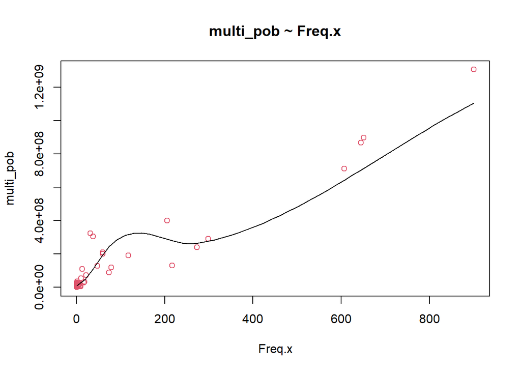

```r
scatter.smooth(x=h_y_m_comuna_corr_01$Freq.x, y=h_y_m_comuna_corr_01$multi_pob, main="multi_pob ~ Freq.x",
     xlab = "Freq.x",
     ylab = "multi_pob",
           col = 2)
```

### 7.2 Outliers

Hemos demostrado en el punto 5.7.2 de [aquí](https://rpubs.com/dataintelligence/expansion_viviendas_001) que la exclusión de ouliers no genera ninguna mejora en el modelo de regresión.

### 7.3 Modelo lineal

Aplicaremos un análisis de regresión lineal del ingreso expandido por zona sobre las frecuencias de respuestas zonales.

```r
linearMod <- lm( multi_pob~(Freq.x) , data=h_y_m_comuna_corr_01)
summary(linearMod)
```

```
##
## Call:
## lm(formula = multi_pob ~ (Freq.x), data = h_y_m_comuna_corr_01)
##
## Residuals:
##        Min         1Q     Median         3Q        Max
## -176575935  -24774024  -15814472    9039800  257395862
##
## Coefficients:
##             Estimate Std. Error t value Pr(>|t|)
## (Intercept) 25844086   11995944   2.154   0.0365 *
## Freq.x       1296951      54668  23.724   <2e-16 ***
## ---
## Signif. codes:  0 '***' 0.001 '**' 0.01 '*' 0.05 '.' 0.1 ' ' 1
##
## Residual standard error: 75260000 on 46 degrees of freedom
## Multiple R-squared:  0.9244, Adjusted R-squared:  0.9228
## F-statistic: 562.8 on 1 and 46 DF,  p-value: < 2.2e-16
```

### 7.4 Gráfica de la recta de regresión lineal

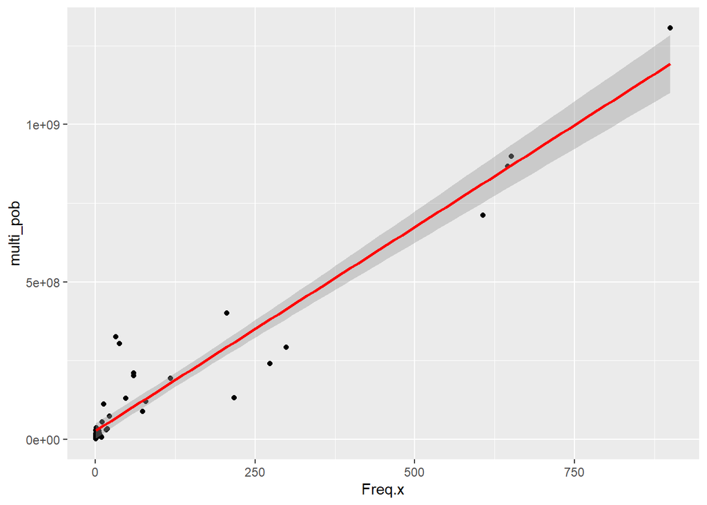

```r
ggplot(h_y_m_comuna_corr_01, aes(x = Freq.x , y = multi_pob)) +
  geom_point() +
  stat_smooth(method = "lm", col = "red")
```

## 8 Modelos alternativos

### 8.1 Modelo cuadrático

$$\hat Y = \beta_0 + \beta_1 X^2$$

```r
linearMod <- lm( multi_pob~(Freq.x^2) , data=h_y_m_comuna_corr_01)
summary(linearMod)
```

```
##
## Call:
## lm(formula = multi_pob ~ (Freq.x^2), data = h_y_m_comuna_corr_01)
##
## Residuals:
##        Min         1Q     Median         3Q        Max
## -176575935  -24774024  -15814472    9039800  257395862
##
## Coefficients:
##             Estimate Std. Error t value Pr(>|t|)
## (Intercept) 25844086   11995944   2.154   0.0365 *
## Freq.x       1296951      54668  23.724   <2e-16 ***
## ---
## Signif. codes:  0 '***' 0.001 '**' 0.01 '*' 0.05 '.' 0.1 ' ' 1
##
## Residual standard error: 75260000 on 46 degrees of freedom
## Multiple R-squared:  0.9244, Adjusted R-squared:  0.9228
## F-statistic: 562.8 on 1 and 46 DF,  p-value: < 2.2e-16
```

### 8.2 Modelo cúbico

$$\hat Y = \beta_0 + \beta_1 X^3$$

```r
linearMod <- lm( multi_pob~(Freq.x^3) , data=h_y_m_comuna_corr_01)
summary(linearMod)
```

```
##
## Call:
## lm(formula = multi_pob ~ (Freq.x^3), data = h_y_m_comuna_corr_01)
##
## Residuals:
##        Min         1Q     Median         3Q        Max
## -176575935  -24774024  -15814472    9039800  257395862
##
## Coefficients:
##             Estimate Std. Error t value Pr(>|t|)
## (Intercept) 25844086   11995944   2.154   0.0365 *
## Freq.x       1296951      54668  23.724   <2e-16 ***
## ---
## Signif. codes:  0 '***' 0.001 '**' 0.01 '*' 0.05 '.' 0.1 ' ' 1
##
## Residual standard error: 75260000 on 46 degrees of freedom
## Multiple R-squared:  0.9244, Adjusted R-squared:  0.9228
## F-statistic: 562.8 on 1 and 46 DF,  p-value: < 2.2e-16
```

### 8.3 Modelo logarítmico

$$\hat Y = \beta_0 + \beta_1 ln X$$

```r
linearMod <- lm( multi_pob~log(Freq.x) , data=h_y_m_comuna_corr_01)
summary(linearMod)
```

```
##
## Call:
## lm(formula = multi_pob ~ log(Freq.x), data = h_y_m_comuna_corr_01)
##
## Residuals:
##        Min         1Q     Median         3Q        Max
## -296582274 -122614341   26489158   74789583  747425964
##
## Coefficients:
##              Estimate Std. Error t value Pr(>|t|)
## (Intercept) -71225035   37567237  -1.896   0.0643 .
## log(Freq.x)  92662313   11669745   7.940 3.62e-10 ***
## ---
## Signif. codes:  0 '***' 0.001 '**' 0.01 '*' 0.05 '.' 0.1 ' ' 1
##
## Residual standard error: 177800000 on 46 degrees of freedom
## Multiple R-squared:  0.5782, Adjusted R-squared:  0.569
## F-statistic: 63.05 on 1 and 46 DF,  p-value: 3.621e-10
```

### 8.4 Modelo exponencial

$$\hat Y = \beta_0 + \beta_1 e^X$$

No es aplicable sin una transformación pues los valores elevados a $e$ de Freq.x tienden a infinito.

### 8.5 Modelo con raíz cuadrada

$$\hat Y = \beta_0 + \beta_1 \sqrt {X}$$

```r
linearMod <- lm( multi_pob~sqrt(Freq.x) , data=h_y_m_comuna_corr_01)
summary(linearMod)
```

```
##
## Call:
## lm(formula = multi_pob ~ sqrt(Freq.x), data = h_y_m_comuna_corr_01)
##
## Residuals:
##        Min         1Q     Median         3Q        Max
## -301793193  -33984265   23583233   32272741  368019872
##
## Coefficients:
##               Estimate Std. Error t value Pr(>|t|)
## (Intercept)  -55673188   19510971  -2.853  0.00646 **
## sqrt(Freq.x)  33139329    2022061  16.389  < 2e-16 ***
## ---
## Signif. codes:  0 '***' 0.001 '**' 0.01 '*' 0.05 '.' 0.1 ' ' 1
##
## Residual standard error: 104700000 on 46 degrees of freedom
## Multiple R-squared:  0.8538, Adjusted R-squared:  0.8506
## F-statistic: 268.6 on 1 and 46 DF,  p-value: < 2.2e-16
```

### 8.6 Modelo raíz-raíz

$$\hat Y = {\beta_0}^2 + 2 \beta_0 \beta_1 \sqrt{X}+ \beta_1^2 X$$

```r
linearMod <- lm( sqrt(multi_pob)~sqrt(Freq.x) , data=h_y_m_comuna_corr_01)
summary(linearMod)
```

```
##
## Call:
## lm(formula = sqrt(multi_pob) ~ sqrt(Freq.x), data = h_y_m_comuna_corr_01)
##
## Residuals:
##     Min      1Q  Median      3Q     Max
## -6410.6 -1727.0  -577.6  1102.9  9776.1
##
## Coefficients:
##              Estimate Std. Error t value Pr(>|t|)
## (Intercept)   2260.52     542.19   4.169 0.000134 ***
## sqrt(Freq.x)  1057.83      56.19  18.825  < 2e-16 ***
## ---
## Signif. codes:  0 '***' 0.001 '**' 0.01 '*' 0.05 '.' 0.1 ' ' 1
##
## Residual standard error: 2909 on 46 degrees of freedom
## Multiple R-squared:  0.8851, Adjusted R-squared:  0.8826
## F-statistic: 354.4 on 1 and 46 DF,  p-value: < 2.2e-16
```

### 8.7 Modelo log-raíz

$$\hat Y = e^{\beta_0 + \beta_1 \sqrt{X}}$$

```r
linearMod <- lm( log(multi_pob)~sqrt(Freq.x) , data=h_y_m_comuna_corr_01)
summary(linearMod)
```

```
##
## Call:
## lm(formula = log(multi_pob) ~ sqrt(Freq.x), data = h_y_m_comuna_corr_01)
##
## Residuals:
##     Min      1Q  Median      3Q     Max
## -3.7059 -0.6706  0.0798  0.7747  2.4222
##
## Coefficients:
##              Estimate Std. Error t value Pr(>|t|)
## (Intercept)  16.01166    0.22051   72.61  < 2e-16 ***
## sqrt(Freq.x)  0.20589    0.02285    9.01 1.01e-11 ***
## ---
## Signif. codes:  0 '***' 0.001 '**' 0.01 '*' 0.05 '.' 0.1 ' ' 1
##
## Residual standard error: 1.183 on 46 degrees of freedom
## Multiple R-squared:  0.6383, Adjusted R-squared:  0.6304
## F-statistic: 81.17 on 1 and 46 DF,  p-value: 1.007e-11
```

### 8.8 Modelo raíz-log

$$\hat Y = {\beta_0}^2 + 2 \beta_0 \beta_1 \ln{X}+ \beta_1^2 ln^2X$$

```r
linearMod <- lm( sqrt(multi_pob)~log(Freq.x) , data=h_y_m_comuna_corr_01)
summary(linearMod)
```

```
##
## Call:
## lm(formula = sqrt(multi_pob) ~ log(Freq.x), data = h_y_m_comuna_corr_01)
##
## Residuals:
##     Min      1Q  Median      3Q     Max
## -7512.9 -2951.6   719.8  1934.2 12397.0
##
## Coefficients:
##             Estimate Std. Error t value Pr(>|t|)
## (Intercept)    779.6      848.3   0.919    0.363
## log(Freq.x)   3376.7      263.5  12.814   <2e-16 ***
## ---
## Signif. codes:  0 '***' 0.001 '**' 0.01 '*' 0.05 '.' 0.1 ' ' 1
##
## Residual standard error: 4016 on 46 degrees of freedom
## Multiple R-squared:  0.7812, Adjusted R-squared:  0.7764
## F-statistic: 164.2 on 1 and 46 DF,  p-value: < 2.2e-16
```

### 8.9 Modelo log-log

$$\hat Y = e^{\beta_0+\beta_1 ln{X}}$$

```r
linearMod <- lm( log(multi_pob)~log(Freq.x) , data=h_y_m_comuna_corr_01)
summary(linearMod)
```

```
##
## Call:
## lm(formula = log(multi_pob) ~ log(Freq.x), data = h_y_m_comuna_corr_01)
##
## Residuals:
##      Min       1Q   Median       3Q      Max
## -2.92484 -0.50062 -0.04468  0.56296  1.72303
##
## Coefficients:
##             Estimate Std. Error t value Pr(>|t|)
## (Intercept) 15.43645    0.18955   81.44   <2e-16 ***
## log(Freq.x)  0.77930    0.05888   13.23   <2e-16 ***
## ---
## Signif. codes:  0 '***' 0.001 '**' 0.01 '*' 0.05 '.' 0.1 ' ' 1
##
## Residual standard error: 0.8972 on 46 degrees of freedom
## Multiple R-squared:  0.792,  Adjusted R-squared:  0.7875
## F-statistic: 175.2 on 1 and 46 DF,  p-value: < 2.2e-16
```

## 9 Modelo raiz-raiz (**raiz-raiz**)

### 9.1 Diagrama de dispersión sobre **raiz-raiz**

Desplegamos una curva suavizada por loess en el diagrama de dispersión.

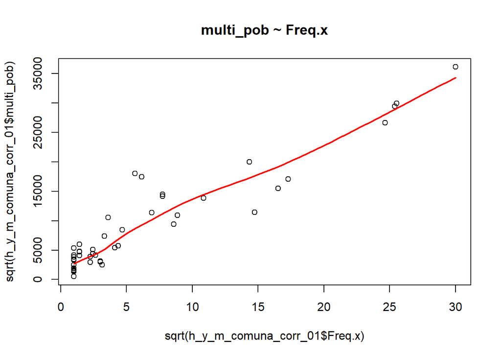

```r
scatter.smooth(x=sqrt(h_y_m_comuna_corr_01$Freq.x), y=sqrt(h_y_m_comuna_corr_01$multi_pob), lpars = list(col = "red", lwd = 2, lty = 1), main="multi_pob ~ Freq.x")
```

### 9.2 Modelo **raiz-raiz**

Observemos nuevamente el resultado sobre **raiz-raiz**.

```r
linearMod <- lm(sqrt( multi_pob)~sqrt(Freq.x) , data=h_y_m_comuna_corr_01)
summary(linearMod)
```

```
##
## Call:
## lm(formula = sqrt(multi_pob) ~ sqrt(Freq.x), data = h_y_m_comuna_corr_01)
##
## Residuals:
##     Min      1Q  Median      3Q     Max
## -6410.6 -1727.0  -577.6  1102.9  9776.1
##
## Coefficients:
##              Estimate Std. Error t value Pr(>|t|)
## (Intercept)   2260.52     542.19   4.169 0.000134 ***
## sqrt(Freq.x)  1057.83      56.19  18.825  < 2e-16 ***
## ---
## Signif. codes:  0 '***' 0.001 '**' 0.01 '*' 0.05 '.' 0.1 ' ' 1
##
## Residual standard error: 2909 on 46 degrees of freedom
## Multiple R-squared:  0.8851, Adjusted R-squared:  0.8826
## F-statistic: 354.4 on 1 and 46 DF,  p-value: < 2.2e-16
```

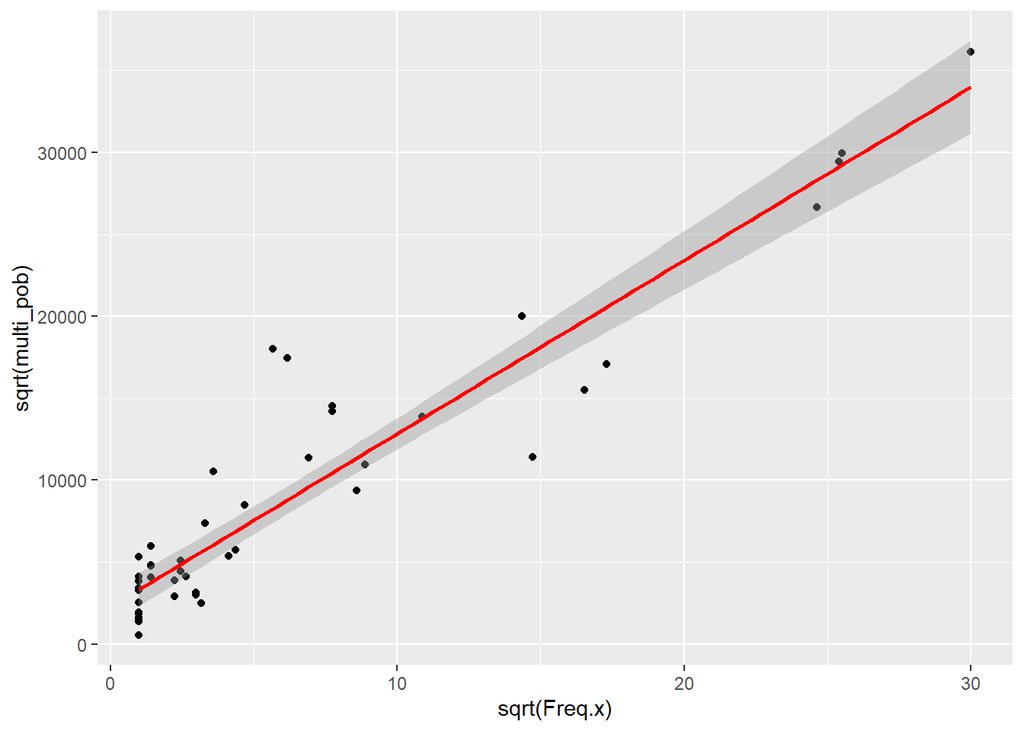

```r
ggplot(h_y_m_comuna_corr_01, aes(x = sqrt(Freq.x) , y = sqrt(multi_pob))) +
  geom_point() +
  stat_smooth(method = "lm", col = "red")
```

### 9.3 Análisis de residuos

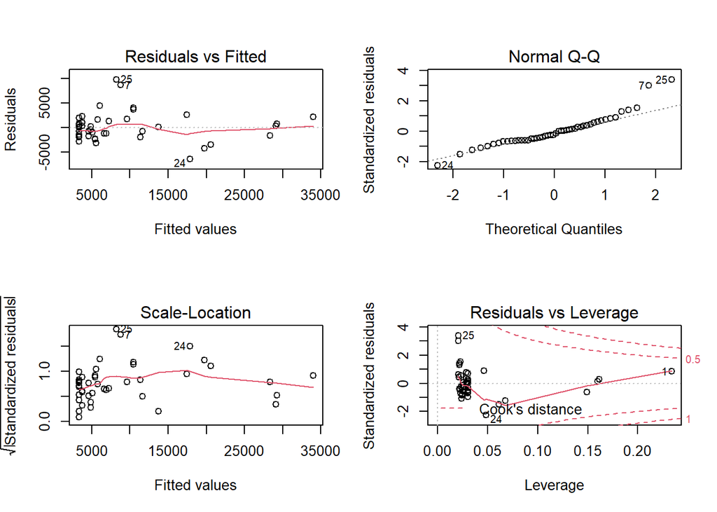

```r
par(mfrow = c (2,2))
plot(linearMod)
```

### 9.4 Ecuación del modelo

$$\hat Y = {2260.52}^2 + 2 \cdot 2260.52 \cdot 1057.83 \sqrt{X}+ 1057.83^2 \cdot X$$

## 10 Aplicación la regresión a los valores de la variable a nivel de zona

Esta nueva variable se llamará: est_ing

```r
h_y_m_comuna_corr_01$est_ing <- {2260.52}^2 + 2 * 2260.52 * 1057.83 * sqrt(h_y_m_comuna_corr_01$Freq.x)+  1057.83^2 * h_y_m_comuna_corr_01$Freq.x

r3_100 <- h_y_m_comuna_corr_01[c(1:100),]
kbl(r3_100) %>%
  kable_styling(bootstrap_options = c("striped", "hover")) %>%
  kable_paper() %>%
  scroll_box(width = "100%", height = "300px")
```

|  | zona | código.x | Freq.x | anio | comuna.x | promedio_i | año | personas | Ingresos_expandidos | Freq.y | p_poblacional | código.y | multi_pob | est_ing |
| --- | --- | --- | --- | --- | --- | --- | --- | --- | --- | --- | --- | --- | --- | --- |
| 1 | 2103012003 | 02103 | 900 | 2017 | Sierra Gorda | 322997.9 | 2017 | 10186 | 3290056742 | 4045 | 0.3971137 | 02103 | 1306526558.3 | 1155688581 |
| 2 | 2103012008 | 02103 | 645 | 2017 | Sierra Gorda | 322997.9 | 2017 | 10186 | 3290056742 | 2684 | 0.2634989 | 02103 | 866926398.6 | 848327956 |
| 3 | 2103012901 | 02103 | 1 | 2017 | Sierra Gorda | 322997.9 | 2017 | 10186 | 3290056742 | 8 | 0.0007854 | 02103 | 2583983.3 | 11011447 |
| 4 | 2103022006 | 02103 | 118 | 2017 | Sierra Gorda | 322997.9 | 2017 | 10186 | 3290056742 | 596 | 0.0585117 | 02103 | 192506756.2 | 189103617 |
| 5 | 2103022007 | 02103 | 299 | 2017 | Sierra Gorda | 322997.9 | 2017 | 10186 | 3290056742 | 905 | 0.0888474 | 02103 | 292313111.3 | 422389252 |
| 6 | 2103022008 | 02103 | 273 | 2017 | Sierra Gorda | 322997.9 | 2017 | 10186 | 3290056742 | 744 | 0.0730414 | 02103 | 240310447.3 | 389617859 |
| 7 | 2103032002 | 02103 | 38 | 2017 | Sierra Gorda | 322997.9 | 2017 | 10186 | 3290056742 | 942 | 0.0924799 | 02103 | 304264034.1 | 77113373 |
| 8 | 2103042001 | 02103 | 22 | 2017 | Sierra Gorda | 322997.9 | 2017 | 10186 | 3290056742 | 223 | 0.0218928 | 02103 | 72028534.6 | 52159920 |
| 9 | 2103042005 | 02103 | 1 | 2017 | Sierra Gorda | 322997.9 | 2017 | 10186 | 3290056742 | 11 | 0.0010799 | 02103 | 3552977.0 | 11011447 |
| 10 | 2103992999 | 02103 | 9 | 2017 | Sierra Gorda | 322997.9 | 2017 | 10186 | 3290056742 | 28 | 0.0027489 | 02103 | 9043941.6 | 29528465 |
| 11 | 2104012008 | 02104 | 1 | 2017 | Taltal | 288653.8 | 2017 | 13317 | 3844002134 | 59 | 0.0044304 | 02104 | 17030571.9 | 11011447 |
| 12 | 2104022015 | 02104 | 7 | 2017 | Taltal | 288653.8 | 2017 | 13317 | 3844002134 | 59 | 0.0044304 | 02104 | 17030571.9 | 25596265 |
| 13 | 2104022022 | 02104 | 2 | 2017 | Taltal | 288653.8 | 2017 | 13317 | 3844002134 | 57 | 0.0042802 | 02104 | 16453264.4 | 14111424 |
| 14 | 2104022901 | 02104 | 1 | 2017 | Taltal | 288653.8 | 2017 | 13317 | 3844002134 | 22 | 0.0016520 | 02104 | 6350382.7 | 11011447 |
| 15 | 2104032025 | 02104 | 1 | 2017 | Taltal | 288653.8 | 2017 | 13317 | 3844002134 | 12 | 0.0009011 | 02104 | 3463845.1 | 11011447 |
| 16 | 2104042020 | 02104 | 60 | 2017 | Taltal | 288653.8 | 2017 | 13317 | 3844002134 | 729 | 0.0547421 | 02104 | 210428591.7 | 109295231 |
| 17 | 2104052026 | 02104 | 2 | 2017 | Taltal | 288653.8 | 2017 | 13317 | 3844002134 | 80 | 0.0060074 | 02104 | 23092300.9 | 14111424 |
| 18 | 2104052027 | 02104 | 1 | 2017 | Taltal | 288653.8 | 2017 | 13317 | 3844002134 | 51 | 0.0038297 | 02104 | 14721341.8 | 11011447 |
| 19 | 2104082013 | 02104 | 74 | 2017 | Taltal | 288653.8 | 2017 | 13317 | 3844002134 | 305 | 0.0229031 | 02104 | 88039397.1 | 129056819 |
| 20 | 2104092002 | 02104 | 19 | 2017 | Taltal | 288653.8 | 2017 | 13317 | 3844002134 | 114 | 0.0085605 | 02104 | 32906528.7 | 47217431 |
| 21 | 2104092012 | 02104 | 79 | 2017 | Taltal | 288653.8 | 2017 | 13317 | 3844002134 | 414 | 0.0310881 | 02104 | 119502657.0 | 136019007 |
| 22 | 2201022005 | 02201 | 651 | 2017 | Calama | 238080.9 | 2017 | 165731 | 39457387800 | 3774 | 0.0227718 | 02201 | 898517365.8 | 855605606 |
| 23 | 2201032006 | 02201 | 5 | 2017 | Calama | 238080.9 | 2017 | 165731 | 39457387800 | 36 | 0.0002172 | 02201 | 8570912.9 | 21398949 |
| 24 | 2201052005 | 02201 | 217 | 2017 | Calama | 238080.9 | 2017 | 165731 | 39457387800 | 549 | 0.0033126 | 02201 | 130706421.3 | 318384388 |
| 25 | 2201082002 | 02201 | 32 | 2017 | Calama | 238080.9 | 2017 | 165731 | 39457387800 | 1364 | 0.0082302 | 02201 | 324742365.4 | 67971947 |
| 26 | 2201082012 | 02201 | 11 | 2017 | Calama | 238080.9 | 2017 | 165731 | 39457387800 | 227 | 0.0013697 | 02201 | 54044367.3 | 33280729 |
| 27 | 2201122002 | 02201 | 2 | 2017 | Calama | 238080.9 | 2017 | 165731 | 39457387800 | 151 | 0.0009111 | 02201 | 35950217.9 | 14111424 |
| 28 | 2201122005 | 02201 | 10 | 2017 | Calama | 238080.9 | 2017 | 165731 | 39457387800 | 26 | 0.0001569 | 02201 | 6190103.7 | 31423561 |
| 29 | 2201132004 | 02201 | 48 | 2017 | Calama | 238080.9 | 2017 | 165731 | 39457387800 | 542 | 0.0032704 | 02201 | 129039854.9 | 91956232 |
| 30 | 2201132010 | 02201 | 6 | 2017 | Calama | 238080.9 | 2017 | 165731 | 39457387800 | 108 | 0.0006517 | 02201 | 25712738.6 | 23538641 |

[output cut: 70 more lines]

## 11 División del valor estimado entre la población total de la zona para obtener el ingreso medio por zona

$$Ingreso \_ Medio\_zona = est\_ing / (personas * p\_poblacional)$$

```r
h_y_m_comuna_corr_01$ing_medio_zona <- h_y_m_comuna_corr_01$est_ing  /( h_y_m_comuna_corr_01$personas  * h_y_m_comuna_corr_01$p_poblacional)

r3_100 <- h_y_m_comuna_corr_01[c(1:100),]
kbl(r3_100) %>%
  kable_styling(bootstrap_options = c("striped", "hover")) %>%
  kable_paper() %>%
  scroll_box(width = "100%", height = "300px")
```

|  | zona | código.x | Freq.x | anio | comuna.x | promedio_i | año | personas | Ingresos_expandidos | Freq.y | p_poblacional | código.y | multi_pob | est_ing | ing_medio_zona |
| --- | --- | --- | --- | --- | --- | --- | --- | --- | --- | --- | --- | --- | --- | --- | --- |
| 1 | 2103012003 | 02103 | 900 | 2017 | Sierra Gorda | 322997.9 | 2017 | 10186 | 3290056742 | 4045 | 0.3971137 | 02103 | 1306526558.3 | 1155688581 | 285707.93 |
| 2 | 2103012008 | 02103 | 645 | 2017 | Sierra Gorda | 322997.9 | 2017 | 10186 | 3290056742 | 2684 | 0.2634989 | 02103 | 866926398.6 | 848327956 | 316068.54 |
| 3 | 2103012901 | 02103 | 1 | 2017 | Sierra Gorda | 322997.9 | 2017 | 10186 | 3290056742 | 8 | 0.0007854 | 02103 | 2583983.3 | 11011447 | 1376430.84 |
| 4 | 2103022006 | 02103 | 118 | 2017 | Sierra Gorda | 322997.9 | 2017 | 10186 | 3290056742 | 596 | 0.0585117 | 02103 | 192506756.2 | 189103617 | 317287.95 |
| 5 | 2103022007 | 02103 | 299 | 2017 | Sierra Gorda | 322997.9 | 2017 | 10186 | 3290056742 | 905 | 0.0888474 | 02103 | 292313111.3 | 422389252 | 466728.46 |
| 6 | 2103022008 | 02103 | 273 | 2017 | Sierra Gorda | 322997.9 | 2017 | 10186 | 3290056742 | 744 | 0.0730414 | 02103 | 240310447.3 | 389617859 | 523679.92 |
| 7 | 2103032002 | 02103 | 38 | 2017 | Sierra Gorda | 322997.9 | 2017 | 10186 | 3290056742 | 942 | 0.0924799 | 02103 | 304264034.1 | 77113373 | 81861.33 |
| 8 | 2103042001 | 02103 | 22 | 2017 | Sierra Gorda | 322997.9 | 2017 | 10186 | 3290056742 | 223 | 0.0218928 | 02103 | 72028534.6 | 52159920 | 233900.99 |
| 9 | 2103042005 | 02103 | 1 | 2017 | Sierra Gorda | 322997.9 | 2017 | 10186 | 3290056742 | 11 | 0.0010799 | 02103 | 3552977.0 | 11011447 | 1001040.61 |
| 10 | 2103992999 | 02103 | 9 | 2017 | Sierra Gorda | 322997.9 | 2017 | 10186 | 3290056742 | 28 | 0.0027489 | 02103 | 9043941.6 | 29528465 | 1054588.02 |
| 11 | 2104012008 | 02104 | 1 | 2017 | Taltal | 288653.8 | 2017 | 13317 | 3844002134 | 59 | 0.0044304 | 02104 | 17030571.9 | 11011447 | 186634.69 |
| 12 | 2104022015 | 02104 | 7 | 2017 | Taltal | 288653.8 | 2017 | 13317 | 3844002134 | 59 | 0.0044304 | 02104 | 17030571.9 | 25596265 | 433834.99 |
| 13 | 2104022022 | 02104 | 2 | 2017 | Taltal | 288653.8 | 2017 | 13317 | 3844002134 | 57 | 0.0042802 | 02104 | 16453264.4 | 14111424 | 247568.84 |
| 14 | 2104022901 | 02104 | 1 | 2017 | Taltal | 288653.8 | 2017 | 13317 | 3844002134 | 22 | 0.0016520 | 02104 | 6350382.7 | 11011447 | 500520.31 |
| 15 | 2104032025 | 02104 | 1 | 2017 | Taltal | 288653.8 | 2017 | 13317 | 3844002134 | 12 | 0.0009011 | 02104 | 3463845.1 | 11011447 | 917620.56 |
| 16 | 2104042020 | 02104 | 60 | 2017 | Taltal | 288653.8 | 2017 | 13317 | 3844002134 | 729 | 0.0547421 | 02104 | 210428591.7 | 109295231 | 149924.87 |
| 17 | 2104052026 | 02104 | 2 | 2017 | Taltal | 288653.8 | 2017 | 13317 | 3844002134 | 80 | 0.0060074 | 02104 | 23092300.9 | 14111424 | 176392.80 |
| 18 | 2104052027 | 02104 | 1 | 2017 | Taltal | 288653.8 | 2017 | 13317 | 3844002134 | 51 | 0.0038297 | 02104 | 14721341.8 | 11011447 | 215910.72 |
| 19 | 2104082013 | 02104 | 74 | 2017 | Taltal | 288653.8 | 2017 | 13317 | 3844002134 | 305 | 0.0229031 | 02104 | 88039397.1 | 129056819 | 423137.11 |
| 20 | 2104092002 | 02104 | 19 | 2017 | Taltal | 288653.8 | 2017 | 13317 | 3844002134 | 114 | 0.0085605 | 02104 | 32906528.7 | 47217431 | 414187.99 |
| 21 | 2104092012 | 02104 | 79 | 2017 | Taltal | 288653.8 | 2017 | 13317 | 3844002134 | 414 | 0.0310881 | 02104 | 119502657.0 | 136019007 | 328548.33 |
| 22 | 2201022005 | 02201 | 651 | 2017 | Calama | 238080.9 | 2017 | 165731 | 39457387800 | 3774 | 0.0227718 | 02201 | 898517365.8 | 855605606 | 226710.55 |
| 23 | 2201032006 | 02201 | 5 | 2017 | Calama | 238080.9 | 2017 | 165731 | 39457387800 | 36 | 0.0002172 | 02201 | 8570912.9 | 21398949 | 594415.25 |
| 24 | 2201052005 | 02201 | 217 | 2017 | Calama | 238080.9 | 2017 | 165731 | 39457387800 | 549 | 0.0033126 | 02201 | 130706421.3 | 318384388 | 579935.13 |
| 25 | 2201082002 | 02201 | 32 | 2017 | Calama | 238080.9 | 2017 | 165731 | 39457387800 | 1364 | 0.0082302 | 02201 | 324742365.4 | 67971947 | 49832.81 |
| 26 | 2201082012 | 02201 | 11 | 2017 | Calama | 238080.9 | 2017 | 165731 | 39457387800 | 227 | 0.0013697 | 02201 | 54044367.3 | 33280729 | 146611.14 |
| 27 | 2201122002 | 02201 | 2 | 2017 | Calama | 238080.9 | 2017 | 165731 | 39457387800 | 151 | 0.0009111 | 02201 | 35950217.9 | 14111424 | 93453.14 |
| 28 | 2201122005 | 02201 | 10 | 2017 | Calama | 238080.9 | 2017 | 165731 | 39457387800 | 26 | 0.0001569 | 02201 | 6190103.7 | 31423561 | 1208598.48 |
| 29 | 2201132004 | 02201 | 48 | 2017 | Calama | 238080.9 | 2017 | 165731 | 39457387800 | 542 | 0.0032704 | 02201 | 129039854.9 | 91956232 | 169660.95 |
| 30 | 2201132010 | 02201 | 6 | 2017 | Calama | 238080.9 | 2017 | 165731 | 39457387800 | 108 | 0.0006517 | 02201 | 25712738.6 | 23538641 | 217950.38 |

[output cut: 70 more lines]

Guardamos:

```r
saveRDS(h_y_m_comuna_corr_01, "P15/region_02_P15_r.rds")
```

## 12 Referencias

https://rpubs.com/osoramirez/316691

https://dataintelligencechile.shinyapps.io/casenfinal

Manual_de_usuario_Censo_2017_16R.pdf

http://www.censo2017.cl/microdatos/

Censo de Población y Vivienda

https://www.ine.cl/estadisticas/sociales/censos-de-poblacion-y-vivienda/poblacion-y-vivienda

http://r-statistics.co/Linear-Regression.html